# Risk Factor Analysis

## Outcome Variable

**Outcome Variable:** ever_co

## Predictor Variables

**Intervention Variable:** predfeed6

**Adjustment Set:**

- arm
- sex
- month
- brthmon
- W_mage
- meducyrs
- feducyrs
- hhwealth_quart
- hfoodsec
- W_mhtcm
- W_mwtkg
- W_mbmi
- vagbrth
- W_gagebrth
- W_birthwt
- W_birthlen
- W_nrooms
- W_nchldlt5
- W_parity
- impfloor
- impsan
- safeh20
- delta_W_mage
- delta_meducyrs
- delta_feducyrs
- delta_hhwealth_quart
- delta_hfoodsec
- delta_W_mhtcm
- delta_W_mwtkg
- delta_W_mbmi
- delta_vagbrth
- delta_W_gagebrth
- delta_W_birthwt
- delta_W_birthlen
- delta_W_nrooms
- delta_W_nchldlt5
- delta_W_parity
- delta_impfloor
- delta_impsan
- delta_safeh20

## Stratifying Variables

The analysis was stratified on these variable(s):

- agecat
- studyid
- country

## Data Summary

| agecat | studyid | country | predfeed6 | ever_co | n_cell | n |
| --- | --- | --- | --- | --- | --- | --- |
| 0-24 months | EE | PAKISTAN | 1 | 0 | 20 | 48 |
| 0-24 months | EE | PAKISTAN | 1 | 1 | 23 | 48 |
| 0-24 months | EE | PAKISTAN | 0 | 0 | 5 | 48 |
| 0-24 months | EE | PAKISTAN | 0 | 1 | 0 | 48 |
| 0-24 months | GMS-Nepal | NEPAL | 1 | 0 | 279 | 565 |
| 0-24 months | GMS-Nepal | NEPAL | 1 | 1 | 141 | 565 |
| 0-24 months | GMS-Nepal | NEPAL | 0 | 0 | 93 | 565 |
| 0-24 months | GMS-Nepal | NEPAL | 0 | 1 | 52 | 565 |
| 0-24 months | JiVitA-3 | BANGLADESH | 1 | 0 | 11280 | 15902 |
| 0-24 months | JiVitA-3 | BANGLADESH | 1 | 1 | 1121 | 15902 |
| 0-24 months | JiVitA-3 | BANGLADESH | 0 | 0 | 3166 | 15902 |
| 0-24 months | JiVitA-3 | BANGLADESH | 0 | 1 | 335 | 15902 |
| 0-24 months | JiVitA-4 | BANGLADESH | 1 | 0 | 3154 | 4753 |
| 0-24 months | JiVitA-4 | BANGLADESH | 1 | 1 | 549 | 4753 |
| 0-24 months | JiVitA-4 | BANGLADESH | 0 | 0 | 834 | 4753 |
| 0-24 months | JiVitA-4 | BANGLADESH | 0 | 1 | 216 | 4753 |
| 0-24 months | LCNI-5 | MALAWI | 1 | 0 | 44 | 272 |
| 0-24 months | LCNI-5 | MALAWI | 1 | 1 | 3 | 272 |
| 0-24 months | LCNI-5 | MALAWI | 0 | 0 | 212 | 272 |
| 0-24 months | LCNI-5 | MALAWI | 0 | 1 | 13 | 272 |
| 0-24 months | MAL-ED | BANGLADESH | 1 | 0 | 69 | 233 |
| 0-24 months | MAL-ED | BANGLADESH | 1 | 1 | 16 | 233 |
| 0-24 months | MAL-ED | BANGLADESH | 0 | 0 | 127 | 233 |
| 0-24 months | MAL-ED | BANGLADESH | 0 | 1 | 21 | 233 |
| 0-24 months | MAL-ED | BRAZIL | 1 | 0 | 29 | 210 |
| 0-24 months | MAL-ED | BRAZIL | 1 | 1 | 1 | 210 |
| 0-24 months | MAL-ED | BRAZIL | 0 | 0 | 178 | 210 |
| 0-24 months | MAL-ED | BRAZIL | 0 | 1 | 2 | 210 |
| 0-24 months | MAL-ED | INDIA | 1 | 0 | 11 | 219 |
| 0-24 months | MAL-ED | INDIA | 1 | 1 | 0 | 219 |

[output cut: 126 more lines]

The following strata were considered:

- agecat: 0-24 months, studyid: EE, country: PAKISTAN
- agecat: 0-24 months, studyid: GMS-Nepal, country: NEPAL
- agecat: 0-24 months, studyid: JiVitA-3, country: BANGLADESH
- agecat: 0-24 months, studyid: JiVitA-4, country: BANGLADESH
- agecat: 0-24 months, studyid: LCNI-5, country: MALAWI
- agecat: 0-24 months, studyid: MAL-ED, country: BANGLADESH
- agecat: 0-24 months, studyid: MAL-ED, country: BRAZIL
- agecat: 0-24 months, studyid: MAL-ED, country: INDIA
- agecat: 0-24 months, studyid: MAL-ED, country: NEPAL
- agecat: 0-24 months, studyid: MAL-ED, country: PERU
- agecat: 0-24 months, studyid: MAL-ED, country: SOUTH AFRICA
- agecat: 0-24 months, studyid: MAL-ED, country: TANZANIA, UNITED REPUBLIC OF
- agecat: 0-24 months, studyid: SAS-FoodSuppl, country: INDIA
- agecat: 0-6 months, studyid: EE, country: PAKISTAN
- agecat: 0-6 months, studyid: GMS-Nepal, country: NEPAL
- agecat: 0-6 months, studyid: JiVitA-3, country: BANGLADESH
- agecat: 0-6 months, studyid: JiVitA-4, country: BANGLADESH
- agecat: 0-6 months, studyid: LCNI-5, country: MALAWI
- agecat: 0-6 months, studyid: MAL-ED, country: BANGLADESH
- agecat: 0-6 months, studyid: MAL-ED, country: BRAZIL
- agecat: 0-6 months, studyid: MAL-ED, country: INDIA
- agecat: 0-6 months, studyid: MAL-ED, country: NEPAL
- agecat: 0-6 months, studyid: MAL-ED, country: PERU
- agecat: 0-6 months, studyid: MAL-ED, country: SOUTH AFRICA
- agecat: 0-6 months, studyid: MAL-ED, country: TANZANIA, UNITED REPUBLIC OF
- agecat: 0-6 months, studyid: SAS-FoodSuppl, country: INDIA
- agecat: 6-24 months, studyid: EE, country: PAKISTAN
- agecat: 6-24 months, studyid: GMS-Nepal, country: NEPAL
- agecat: 6-24 months, studyid: JiVitA-3, country: BANGLADESH
- agecat: 6-24 months, studyid: JiVitA-4, country: BANGLADESH
- agecat: 6-24 months, studyid: LCNI-5, country: MALAWI
- agecat: 6-24 months, studyid: MAL-ED, country: BANGLADESH
- agecat: 6-24 months, studyid: MAL-ED, country: BRAZIL
- agecat: 6-24 months, studyid: MAL-ED, country: INDIA
- agecat: 6-24 months, studyid: MAL-ED, country: NEPAL
- agecat: 6-24 months, studyid: MAL-ED, country: PERU
- agecat: 6-24 months, studyid: MAL-ED, country: SOUTH AFRICA
- agecat: 6-24 months, studyid: MAL-ED, country: TANZANIA, UNITED REPUBLIC OF
- agecat: 6-24 months, studyid: SAS-FoodSuppl, country: INDIA

### Dropped Strata

Some strata were dropped due to rare outcomes:

- agecat: 0-24 months, studyid: EE, country: PAKISTAN
- agecat: 0-24 months, studyid: LCNI-5, country: MALAWI
- agecat: 0-24 months, studyid: MAL-ED, country: BRAZIL
- agecat: 0-24 months, studyid: MAL-ED, country: INDIA
- agecat: 0-24 months, studyid: MAL-ED, country: NEPAL
- agecat: 0-24 months, studyid: MAL-ED, country: PERU
- agecat: 0-24 months, studyid: MAL-ED, country: SOUTH AFRICA
- agecat: 0-24 months, studyid: MAL-ED, country: TANZANIA, UNITED REPUBLIC OF
- agecat: 0-24 months, studyid: SAS-FoodSuppl, country: INDIA
- agecat: 0-6 months, studyid: EE, country: PAKISTAN
- agecat: 0-6 months, studyid: LCNI-5, country: MALAWI
- agecat: 0-6 months, studyid: MAL-ED, country: BANGLADESH
- agecat: 0-6 months, studyid: MAL-ED, country: BRAZIL
- agecat: 0-6 months, studyid: MAL-ED, country: INDIA
- agecat: 0-6 months, studyid: MAL-ED, country: NEPAL
- agecat: 0-6 months, studyid: MAL-ED, country: PERU
- agecat: 0-6 months, studyid: MAL-ED, country: SOUTH AFRICA
- agecat: 0-6 months, studyid: MAL-ED, country: TANZANIA, UNITED REPUBLIC OF
- agecat: 0-6 months, studyid: SAS-FoodSuppl, country: INDIA
- agecat: 6-24 months, studyid: EE, country: PAKISTAN
- agecat: 6-24 months, studyid: LCNI-5, country: MALAWI
- agecat: 6-24 months, studyid: MAL-ED, country: BRAZIL
- agecat: 6-24 months, studyid: MAL-ED, country: INDIA
- agecat: 6-24 months, studyid: MAL-ED, country: NEPAL
- agecat: 6-24 months, studyid: MAL-ED, country: PERU
- agecat: 6-24 months, studyid: MAL-ED, country: SOUTH AFRICA
- agecat: 6-24 months, studyid: MAL-ED, country: TANZANIA, UNITED REPUBLIC OF
- agecat: 6-24 months, studyid: SAS-FoodSuppl, country: INDIA

## Methods Detail

We’re interested in the causal parameters $E[Y_a]$ for all values of $a \in \mathcal{A}$. These parameters represent the mean outcome if, possibly contrary to fact, we intervened to set all units to have $A=a$. Under the randomization and positivity assumptions, these are identified by the statistical parameters $\psi_a=E_W[E_{Y|A,W}(Y|A=a,W)]$. In addition, we’re interested in the mean of $Y$, $E[Y]$ under no intervention (the observed mean). We will estimate these parameters by using SuperLearner to fit the relevant likelihood factors – $E_{Y|A,W}(Y|A=a,W)$ and $p(A=a|W)$, and then updating our likelihood fit using a joint TMLE.

For unadjusted analyses ($W=\{\}$), initial likelihoods were estimated using Lrnr_glm to estimate the simple $E(Y|A)$ and Lrnr_mean to estimate $p(A)$. For adjusted analyses, a small library containing Lrnr_glmnet, Lrnr_xgboost, and Lrnr_mean was used.

Having estimated these parameters, we will then use the delta method to estimate relative risks and attributable risks relative to a prespecified baseline level of $A$.

# Results Detail

## Results Plots

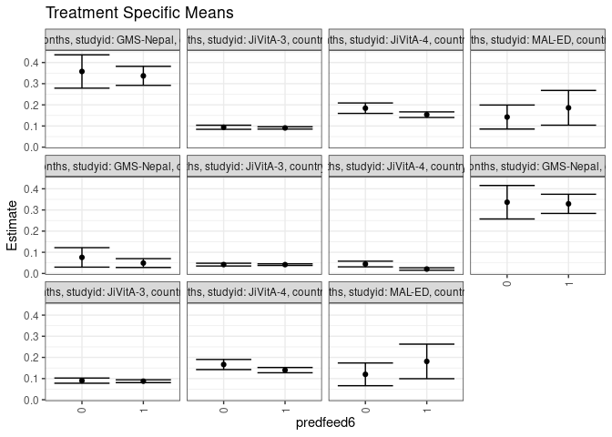

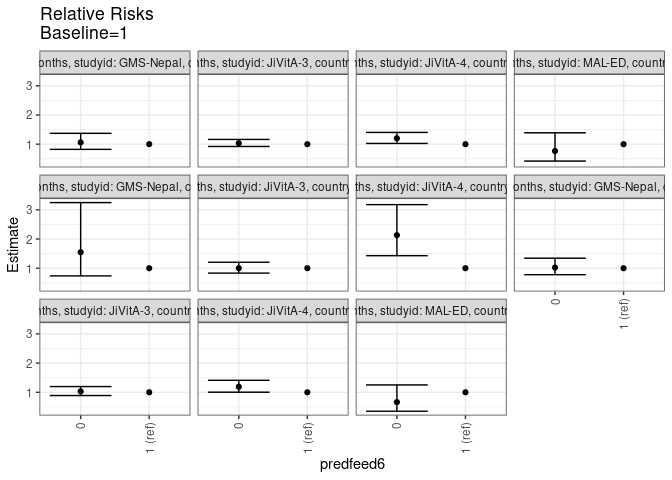

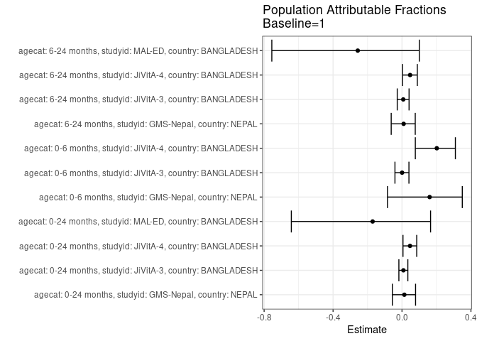

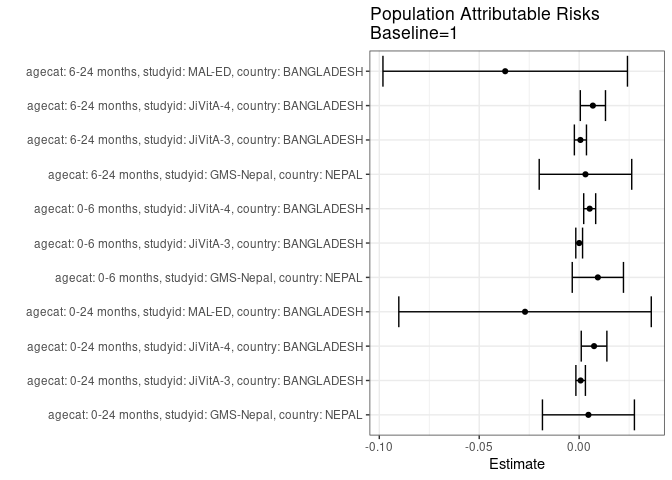

## Results Table

### Parameter: TSM

| agecat | studyid | country | intervention_level | baseline_level | estimate | ci_lower | ci_upper |
| --- | --- | --- | --- | --- | --- | --- | --- |
| 0-24 months | GMS-Nepal | NEPAL | 1 | NA | 0.3369442 | 0.2920003 | 0.3818880 |
| 0-24 months | GMS-Nepal | NEPAL | 0 | NA | 0.3576379 | 0.2788754 | 0.4364004 |
| 0-24 months | JiVitA-3 | BANGLADESH | 1 | NA | 0.0908062 | 0.0853994 | 0.0962130 |
| 0-24 months | JiVitA-3 | BANGLADESH | 0 | NA | 0.0939885 | 0.0842602 | 0.1037168 |
| 0-24 months | JiVitA-4 | BANGLADESH | 1 | NA | 0.1534824 | 0.1402663 | 0.1666986 |
| 0-24 months | JiVitA-4 | BANGLADESH | 0 | NA | 0.1841344 | 0.1594670 | 0.2088017 |
| 0-24 months | MAL-ED | BANGLADESH | 1 | NA | 0.1858673 | 0.1037473 | 0.2679873 |
| 0-24 months | MAL-ED | BANGLADESH | 0 | NA | 0.1423088 | 0.0855853 | 0.1990323 |
| 0-6 months | GMS-Nepal | NEPAL | 1 | NA | 0.0490404 | 0.0281694 | 0.0699114 |
| 0-6 months | GMS-Nepal | NEPAL | 0 | NA | 0.0758656 | 0.0298242 | 0.1219070 |
| 0-6 months | JiVitA-3 | BANGLADESH | 1 | NA | 0.0417482 | 0.0378631 | 0.0456332 |
| 0-6 months | JiVitA-3 | BANGLADESH | 0 | NA | 0.0418440 | 0.0352288 | 0.0484592 |
| 0-6 months | JiVitA-4 | BANGLADESH | 1 | NA | 0.0208733 | 0.0150757 | 0.0266708 |
| 0-6 months | JiVitA-4 | BANGLADESH | 0 | NA | 0.0445038 | 0.0311321 | 0.0578755 |
| 6-24 months | GMS-Nepal | NEPAL | 1 | NA | 0.3289697 | 0.2836494 | 0.3742900 |
| 6-24 months | GMS-Nepal | NEPAL | 0 | NA | 0.3365307 | 0.2573335 | 0.4157279 |
| 6-24 months | JiVitA-3 | BANGLADESH | 1 | NA | 0.0875673 | 0.0809454 | 0.0941891 |
| 6-24 months | JiVitA-3 | BANGLADESH | 0 | NA | 0.0902968 | 0.0780006 | 0.1025930 |
| 6-24 months | JiVitA-4 | BANGLADESH | 1 | NA | 0.1399217 | 0.1275171 | 0.1523262 |
| 6-24 months | JiVitA-4 | BANGLADESH | 0 | NA | 0.1664682 | 0.1425633 | 0.1903731 |
| 6-24 months | MAL-ED | BANGLADESH | 1 | NA | 0.1810989 | 0.0994612 | 0.2627367 |
| 6-24 months | MAL-ED | BANGLADESH | 0 | NA | 0.1200158 | 0.0663159 | 0.1737158 |

### Parameter: E(Y)

| agecat | studyid | country | intervention_level | baseline_level | estimate | ci_lower | ci_upper |
| --- | --- | --- | --- | --- | --- | --- | --- |
| 0-24 months | GMS-Nepal | NEPAL | NA | NA | 0.3415929 | 0.3024539 | 0.3807320 |
| 0-24 months | JiVitA-3 | BANGLADESH | NA | NA | 0.0915608 | 0.0867079 | 0.0964137 |
| 0-24 months | JiVitA-4 | BANGLADESH | NA | NA | 0.1609510 | 0.1491579 | 0.1727440 |
| 0-24 months | MAL-ED | BANGLADESH | NA | NA | 0.1587983 | 0.1117681 | 0.2058285 |
| 0-6 months | GMS-Nepal | NEPAL | NA | NA | 0.0584071 | 0.0390530 | 0.0777612 |
| 0-6 months | JiVitA-3 | BANGLADESH | NA | NA | 0.0417690 | 0.0384207 | 0.0451174 |
| 0-6 months | JiVitA-4 | BANGLADESH | NA | NA | 0.0261535 | 0.0207066 | 0.0316005 |
| 6-24 months | GMS-Nepal | NEPAL | NA | NA | 0.3321364 | 0.2929882 | 0.3712847 |
| 6-24 months | JiVitA-3 | BANGLADESH | NA | NA | 0.0882064 | 0.0821266 | 0.0942862 |
| 6-24 months | JiVitA-4 | BANGLADESH | NA | NA | 0.1468045 | 0.1358635 | 0.1577455 |
| 6-24 months | MAL-ED | BANGLADESH | NA | NA | 0.1441048 | 0.0985189 | 0.1896907 |

### Parameter: RR

| agecat | studyid | country | intervention_level | baseline_level | estimate | ci_lower | ci_upper |
| --- | --- | --- | --- | --- | --- | --- | --- |
| 0-24 months | GMS-Nepal | NEPAL | 1 | 1 | 1.0000000 | 1.0000000 | 1.000000 |
| 0-24 months | GMS-Nepal | NEPAL | 0 | 1 | 1.0614160 | 0.8216333 | 1.371176 |
| 0-24 months | JiVitA-3 | BANGLADESH | 1 | 1 | 1.0000000 | 1.0000000 | 1.000000 |
| 0-24 months | JiVitA-3 | BANGLADESH | 0 | 1 | 1.0350450 | 0.9217191 | 1.162304 |
| 0-24 months | JiVitA-4 | BANGLADESH | 1 | 1 | 1.0000000 | 1.0000000 | 1.000000 |
| 0-24 months | JiVitA-4 | BANGLADESH | 0 | 1 | 1.1997097 | 1.0257942 | 1.403111 |
| 0-24 months | MAL-ED | BANGLADESH | 1 | 1 | 1.0000000 | 1.0000000 | 1.000000 |
| 0-24 months | MAL-ED | BANGLADESH | 0 | 1 | 0.7656475 | 0.4217398 | 1.389995 |
| 0-6 months | GMS-Nepal | NEPAL | 1 | 1 | 1.0000000 | 1.0000000 | 1.000000 |
| 0-6 months | GMS-Nepal | NEPAL | 0 | 1 | 1.5470029 | 0.7367634 | 3.248285 |
| 0-6 months | JiVitA-3 | BANGLADESH | 1 | 1 | 1.0000000 | 1.0000000 | 1.000000 |
| 0-6 months | JiVitA-3 | BANGLADESH | 0 | 1 | 1.0022953 | 0.8336642 | 1.205037 |
| 0-6 months | JiVitA-4 | BANGLADESH | 1 | 1 | 1.0000000 | 1.0000000 | 1.000000 |
| 0-6 months | JiVitA-4 | BANGLADESH | 0 | 1 | 2.1320960 | 1.4300432 | 3.178808 |
| 6-24 months | GMS-Nepal | NEPAL | 1 | 1 | 1.0000000 | 1.0000000 | 1.000000 |
| 6-24 months | GMS-Nepal | NEPAL | 0 | 1 | 1.0229840 | 0.7787197 | 1.343868 |
| 6-24 months | JiVitA-3 | BANGLADESH | 1 | 1 | 1.0000000 | 1.0000000 | 1.000000 |
| 6-24 months | JiVitA-3 | BANGLADESH | 0 | 1 | 1.0311708 | 0.8886952 | 1.196488 |
| 6-24 months | JiVitA-4 | BANGLADESH | 1 | 1 | 1.0000000 | 1.0000000 | 1.000000 |
| 6-24 months | JiVitA-4 | BANGLADESH | 0 | 1 | 1.1897243 | 1.0031464 | 1.411004 |
| 6-24 months | MAL-ED | BANGLADESH | 1 | 1 | 1.0000000 | 1.0000000 | 1.000000 |
| 6-24 months | MAL-ED | BANGLADESH | 0 | 1 | 0.6627086 | 0.3508059 | 1.251925 |

### Parameter: PAR

| agecat | studyid | country | intervention_level | baseline_level | estimate | ci_lower | ci_upper |
| --- | --- | --- | --- | --- | --- | --- | --- |
| 0-24 months | GMS-Nepal | NEPAL | 1 | NA | 0.0046488 | -0.0183611 | 0.0276586 |
| 0-24 months | JiVitA-3 | BANGLADESH | 1 | NA | 0.0007546 | -0.0016272 | 0.0031364 |
| 0-24 months | JiVitA-4 | BANGLADESH | 1 | NA | 0.0074686 | 0.0010563 | 0.0138808 |
| 0-24 months | MAL-ED | BANGLADESH | 1 | NA | -0.0270690 | -0.0902349 | 0.0360968 |
| 0-6 months | GMS-Nepal | NEPAL | 1 | NA | 0.0093667 | -0.0034471 | 0.0221805 |
| 0-6 months | JiVitA-3 | BANGLADESH | 1 | NA | 0.0000209 | -0.0016734 | 0.0017152 |
| 0-6 months | JiVitA-4 | BANGLADESH | 1 | NA | 0.0052803 | 0.0022831 | 0.0082774 |
| 6-24 months | GMS-Nepal | NEPAL | 1 | NA | 0.0031667 | -0.0199796 | 0.0263131 |
| 6-24 months | JiVitA-3 | BANGLADESH | 1 | NA | 0.0006391 | -0.0023887 | 0.0036670 |
| 6-24 months | JiVitA-4 | BANGLADESH | 1 | NA | 0.0068828 | 0.0005830 | 0.0131826 |
| 6-24 months | MAL-ED | BANGLADESH | 1 | NA | -0.0369941 | -0.0981690 | 0.0241807 |

### Parameter: PAF

| agecat | studyid | country | intervention_level | baseline_level | estimate | ci_lower | ci_upper |
| --- | --- | --- | --- | --- | --- | --- | --- |
| 0-24 months | GMS-Nepal | NEPAL | 1 | NA | 0.0136091 | -0.0560856 | 0.0787043 |
| 0-24 months | JiVitA-3 | BANGLADESH | 1 | NA | 0.0082415 | -0.0181198 | 0.0339203 |
| 0-24 months | JiVitA-4 | BANGLADESH | 1 | NA | 0.0464027 | 0.0056975 | 0.0854415 |
| 0-24 months | MAL-ED | BANGLADESH | 1 | NA | -0.1704616 | -0.6422099 | 0.1657703 |
| 0-6 months | GMS-Nepal | NEPAL | 1 | NA | 0.1603694 | -0.0843034 | 0.3498318 |
| 0-6 months | JiVitA-3 | BANGLADESH | 1 | NA | 0.0005000 | -0.0409024 | 0.0402557 |
| 0-6 months | JiVitA-4 | BANGLADESH | 1 | NA | 0.2018951 | 0.0772541 | 0.3097000 |
| 6-24 months | GMS-Nepal | NEPAL | 1 | NA | 0.0095345 | -0.0626651 | 0.0768287 |
| 6-24 months | JiVitA-3 | BANGLADESH | 1 | NA | 0.0072460 | -0.0276529 | 0.0409598 |
| 6-24 months | JiVitA-4 | BANGLADESH | 1 | NA | 0.0468841 | 0.0029883 | 0.0888474 |
| 6-24 months | MAL-ED | BANGLADESH | 1 | NA | -0.2567169 | -0.7553704 | 0.1002825 |